# Cohabitation Trends: 2012-2022

Lorae Stojanovic

2024-10-21

## Introduction

This report tracks the rates of young adults living with parents from 2012 to 2022. It presents a comparison of percentages for different age groups and cohabitation types between these two years, and evaluates whether there were significant changes in these percentages.

## Cohabitation Trends in 2012 and 2022

We begin by loading the data and calculating the percentages of individuals living with their parents across different age groups.

```
## ℹ Loading dataduck
```

Statistical Comparison In this section, we compare the percentages between 2012 and 2022 using a z-test to determine if the differences are statistically significant.

Comparison of Cohabitation Trends (2012 vs 2022)

| AGE_bucket | cohabit_bin | percent_2012 | percent_2022 | percent_difference | combined_standard_error | z_score | p_value | significant_change |
| --- | --- | --- | --- | --- | --- | --- | --- | --- |
| 16-17 | 0 | 7.6152764 | 7.2245252 | -0.3907512 | 0.1611297 | -2.4250718 | 0.0153054 | Significant |
| 16-17 | 1 | 0.0453301 | 0.0546629 | 0.0093328 | 0.0151712 | 0.6151638 | 0.5384465 | Not Significant |
| 16-17 | 2 | 2.9762011 | 3.9362743 | 0.9600732 | 0.1168474 | 8.2164734 | 0.0000000 | Significant |
| 16-17 | 3 | 88.5645250 | 88.3177776 | -0.2467474 | 0.1941990 | -1.2705909 | 0.2038742 | Not Significant |
| 16-17 | 9 | 0.7986674 | 0.4667600 | -0.3319074 | 0.0257292 | -12.9000128 | 0.0000000 | Significant |
| 18-19 | 0 | 33.0030763 | 34.6272502 | 1.6241739 | 0.2921563 | 5.5592629 | 0.0000000 | Significant |
| 18-19 | 1 | 0.2636960 | 0.4460701 | 0.1823742 | 0.0376902 | 4.8387654 | 0.0000013 | Significant |
| 18-19 | 2 | 2.3910489 | 3.0122700 | 0.6212211 | 0.0979159 | 6.3444337 | 0.0000000 | Significant |
| 18-19 | 3 | 63.4054937 | 61.5756426 | -1.8298511 | 0.2998262 | -6.1030400 | 0.0000000 | Significant |
| 18-19 | 9 | 0.9366851 | 0.3387671 | -0.5979180 | 0.0322928 | -18.5155416 | 0.0000000 | Significant |
| 20-21 | 0 | 44.7361741 | 47.0591760 | 2.3230019 | 0.3923865 | 5.9201882 | 0.0000000 | Significant |
| 20-21 | 1 | 0.6933082 | 0.7968891 | 0.1035810 | 0.0598006 | 1.7321068 | 0.0832545 | Not Significant |
| 20-21 | 2 | 2.0083562 | 2.5025471 | 0.4941909 | 0.0850522 | 5.8104416 | 0.0000000 | Significant |
| 20-21 | 3 | 51.3315502 | 49.0605084 | -2.2710418 | 0.3912169 | -5.8050715 | 0.0000000 | Significant |
| 20-21 | 9 | 1.2306113 | 0.5808793 | -0.6497319 | 0.0459290 | -14.1464545 | 0.0000000 | Significant |
| 22-23 | 0 | 51.9200553 | 53.1086096 | 1.1885543 | 0.3354544 | 3.5431170 | 0.0003954 | Significant |
| 22-23 | 1 | 0.8949840 | 1.1553281 | 0.2603441 | 0.0717180 | 3.6301067 | 0.0002833 | Significant |
| 22-23 | 2 | 1.6834707 | 2.1247052 | 0.4412345 | 0.1040211 | 4.2417791 | 0.0000222 | Significant |
| 22-23 | 3 | 43.8059379 | 42.8377753 | -0.9681626 | 0.3144898 | -3.0785184 | 0.0020803 | Significant |
| 22-23 | 9 | 1.6955521 | 0.7735818 | -0.9219703 | 0.0477650 | -19.3022324 | 0.0000000 | Significant |
| 24-25 | 0 | 63.3367009 | 63.5734395 | 0.2367386 | 0.2988447 | 0.7921794 | 0.4282561 | Not Significant |
| 24-25 | 1 | 0.9763350 | 1.4114554 | 0.4351204 | 0.0655882 | 6.6341253 | 0.0000000 | Significant |
| 24-25 | 2 | 1.2991404 | 1.7035791 | 0.4044388 | 0.0803933 | 5.0307519 | 0.0000005 | Significant |
| 24-25 | 3 | 32.6915143 | 32.3539063 | -0.3376080 | 0.2928674 | -1.1527672 | 0.2490059 | Not Significant |
| 24-25 | 9 | 1.6963095 | 0.9576197 | -0.7386898 | 0.0489515 | -15.0902412 | 0.0000000 | Significant |
| 26-27 | 0 | 71.9639335 | 72.1024658 | 0.1385323 | 0.2987588 | 0.4636927 | 0.6428679 | Not Significant |
| 26-27 | 1 | 1.0189340 | 1.6321681 | 0.6132342 | 0.0757875 | 8.0914919 | 0.0000000 | Significant |
| 26-27 | 2 | 1.0531694 | 1.3775171 | 0.3243477 | 0.0807853 | 4.0149326 | 0.0000595 | Significant |
| 26-27 | 3 | 24.2311436 | 23.8143158 | -0.4168279 | 0.2920206 | -1.4273921 | 0.1534669 | Not Significant |
| 26-27 | 9 | 1.7328195 | 1.0735332 | -0.6592863 | 0.0485929 | -13.5675424 | 0.0000000 | Significant |
| 28-29 | 0 | 78.2522516 | 77.6190094 | -0.6332422 | 0.2662365 | -2.3784949 | 0.0173835 | Significant |
| 28-29 | 1 | 1.1805551 | 1.6814003 | 0.5008453 | 0.0776843 | 6.4471847 | 0.0000000 | Significant |
| 28-29 | 2 | 0.8792833 | 1.0849514 | 0.2056680 | 0.0683583 | 3.0086788 | 0.0026239 | Significant |
| 28-29 | 3 | 17.8180311 | 18.3071271 | 0.4890960 | 0.2525578 | 1.9365709 | 0.0527978 | Not Significant |
| 28-29 | 9 | 1.8698789 | 1.3075118 | -0.5623671 | 0.0597379 | -9.4139100 | 0.0000000 | Significant |
| 30+ | 0 | 92.6259966 | 92.4821678 | -0.1438289 | 0.0310216 | -4.6364139 | 0.0000035 | Significant |
| 30+ | 1 | 1.0717694 | 1.4354313 | 0.3636620 | 0.0141593 | 25.6835421 | 0.0000000 | Significant |
| 30+ | 2 | 0.2352850 | 0.2633032 | 0.0280182 | 0.0069757 | 4.0165606 | 0.0000591 | Significant |
| 30+ | 3 | 4.4423328 | 4.3358176 | -0.1065152 | 0.0302130 | -3.5254796 | 0.0004227 | Significant |
| 30+ | 9 | 1.6246162 | 1.4832801 | -0.1413361 | 0.0050015 | -28.2588508 | 0.0000000 | Significant |
| Under 16 | 0 | 5.1356506 | 5.5913450 | 0.4556944 | 0.0685970 | 6.6430625 | 0.0000000 | Significant |
| Under 16 | 1 | 0.0014169 | 0.0017133 | 0.0002965 | 0.0008514 | 0.3482009 | 0.7276893 | Not Significant |
| Under 16 | 2 | 6.2682342 | 6.1880031 | -0.0802311 | 0.0807528 | -0.9935399 | 0.3204469 | Not Significant |
| Under 16 | 3 | 88.4959842 | 88.1558141 | -0.3401701 | 0.1080581 | -3.1480297 | 0.0016437 | Significant |
| Under 16 | 9 | 0.0987140 | 0.0631245 | -0.0355895 | 0.0030936 | -11.5043287 | 0.0000000 | Significant |

## Visualizing Cohabitation Trends

In this section, we display bar charts showing the percentage of young adults cohabiting with their parents for the years 2012 and 2022. These charts are broken down by age group.

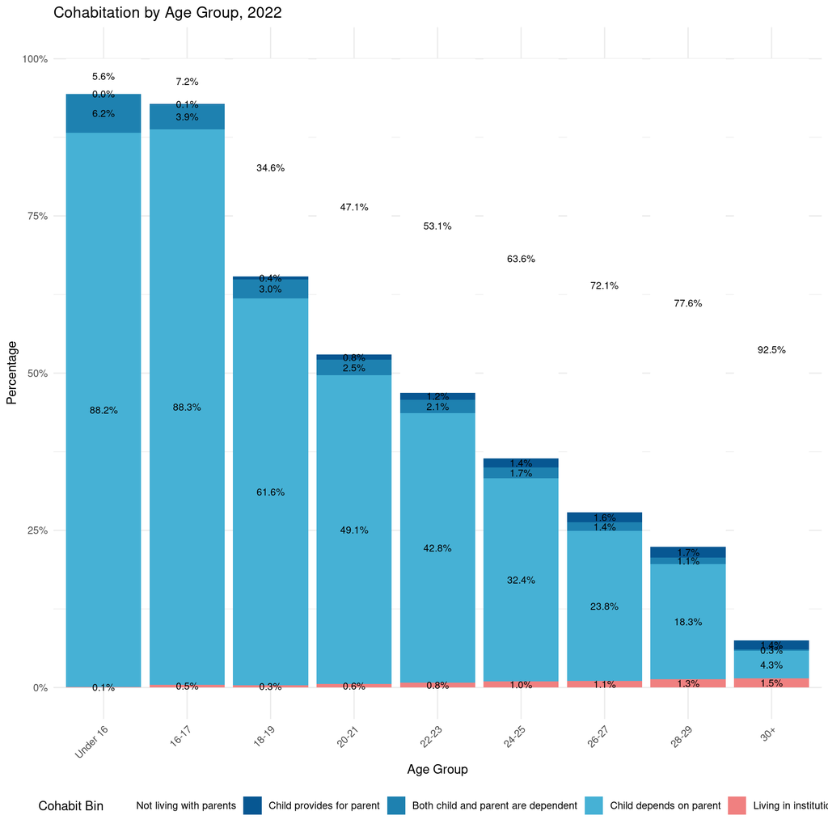

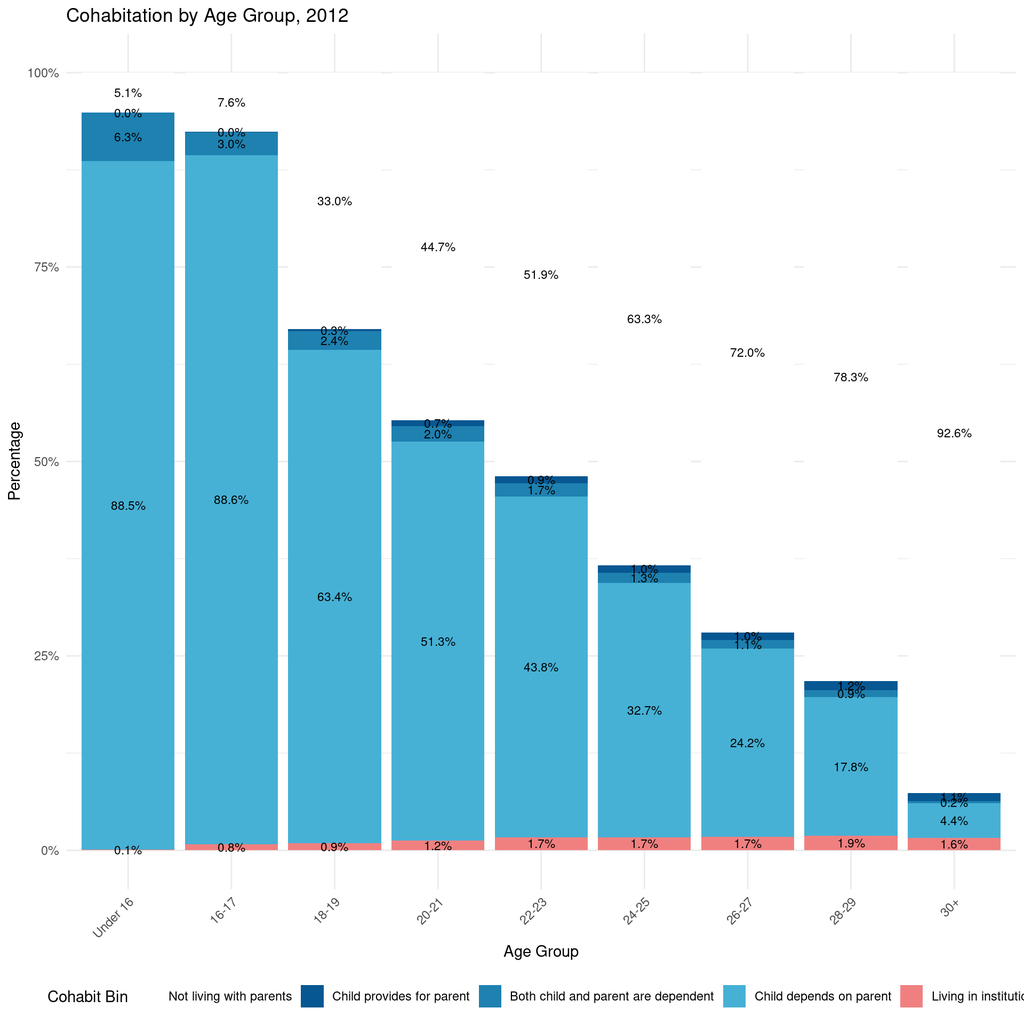

# By Gender

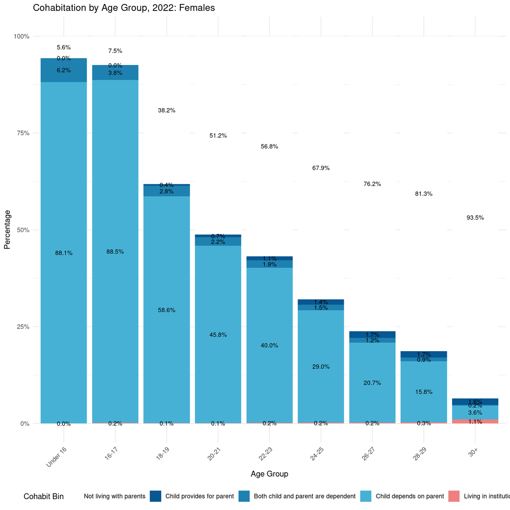

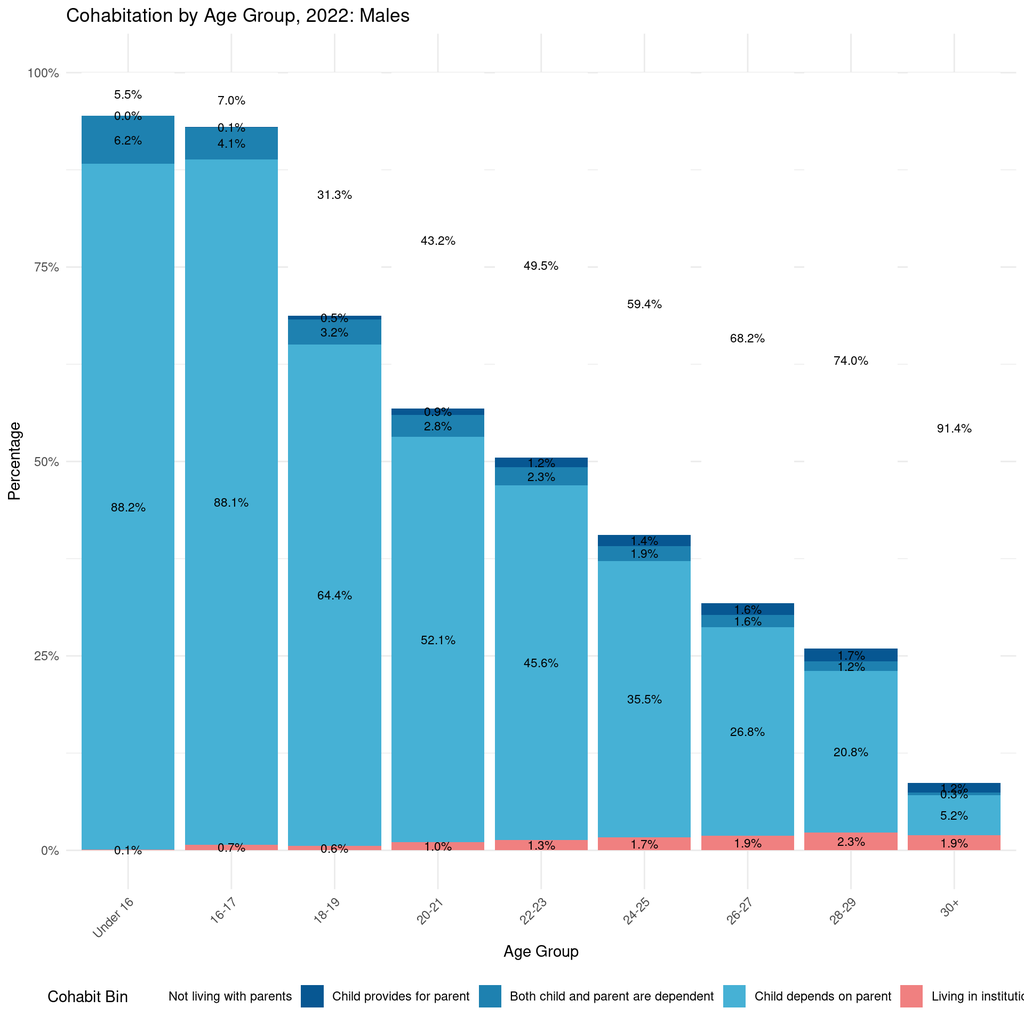

# By Race/Ethnicity

Comparison of Race/Ethnicity Cohabitation Trends (2012 vs 2022)

| RACE_ETH_bucket | percent_2012 | percent_2022 | percent_difference | combined_standard_error | z_score | p_value | significant_change |
| --- | --- | --- | --- | --- | --- | --- | --- |
| AAPI | 5.0363103 | 5.9501005 | 0.9137903 | 0.0144182 | 63.37759 | 0 | Significant |
| AIAN | 0.6677067 | 0.5235104 | -0.1441963 | 0.0060965 | -23.65236 | 0 | Significant |
| Black | 12.2758788 | 11.8780946 | -0.3977841 | 0.0216289 | -18.39135 | 0 | Significant |
| Hispanic | 16.8620948 | 19.0673836 | 2.2052888 | 0.0037424 | 589.26559 | 0 | Significant |
| Multiracial | 2.1205222 | 4.3545888 | 2.2340666 | 0.0280530 | 79.63740 | 0 | Significant |
| Other | 0.1936164 | 0.5706742 | 0.3770578 | 0.0098480 | 38.28768 | 0 | Significant |
| White | 62.8438709 | 57.6556478 | -5.1882231 | 0.0133214 | -389.46666 | 0 | Significant |

# Asian American/Pacific Islanders

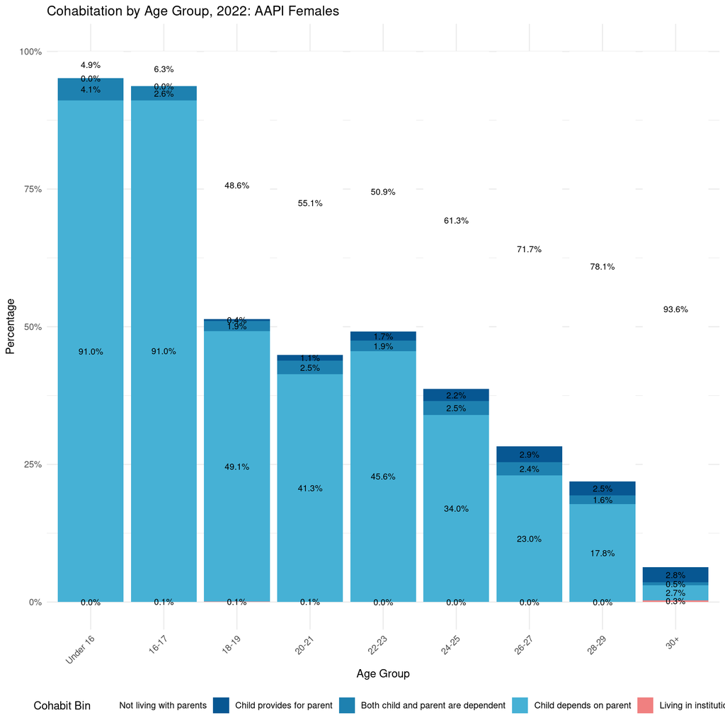

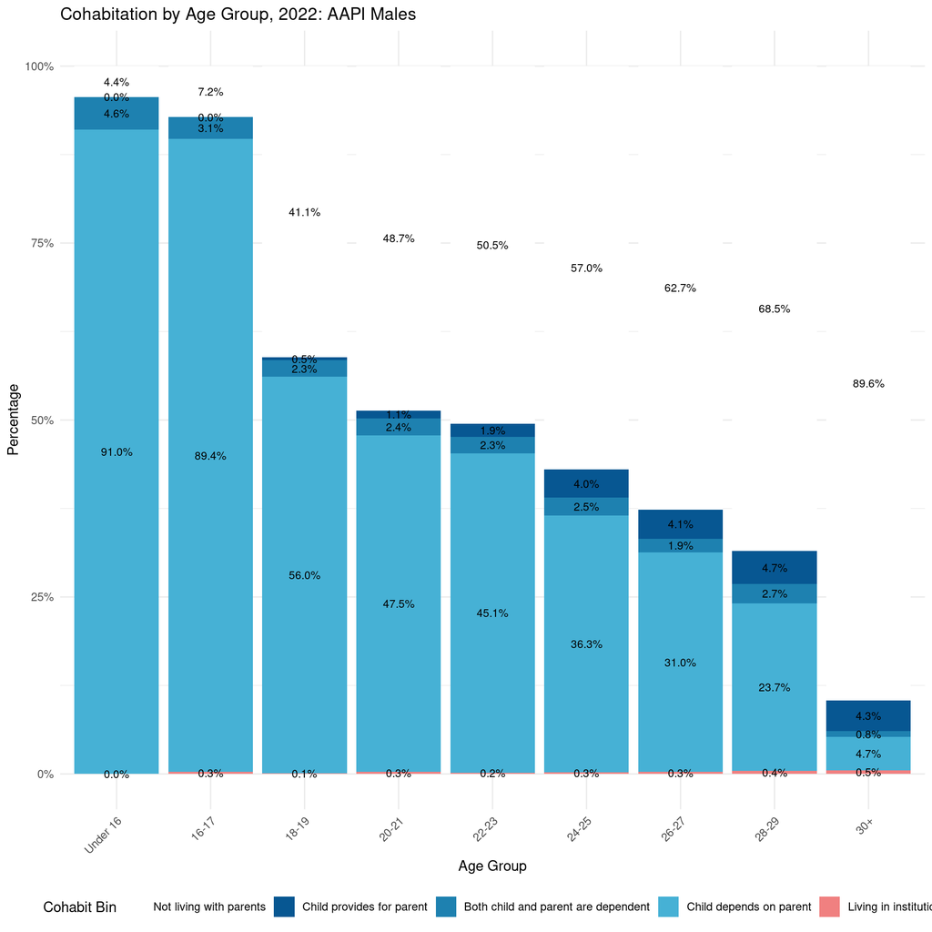

# American Indians / Alaska Natives

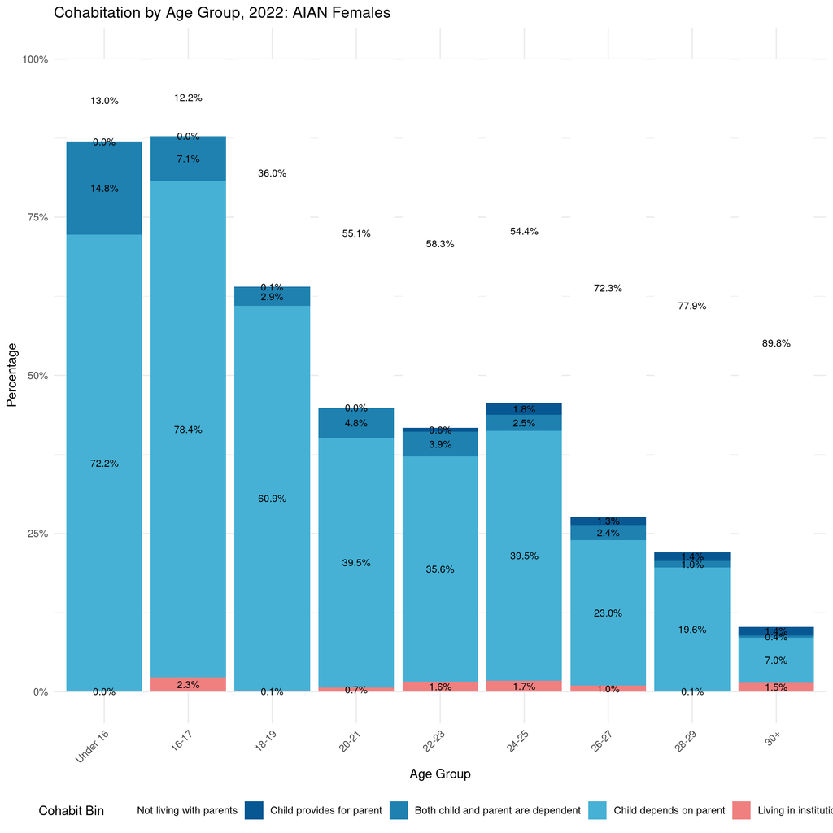

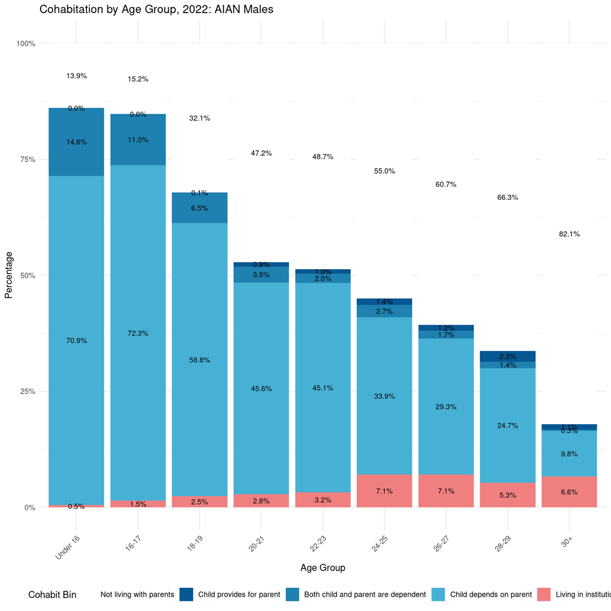

# Black Americans

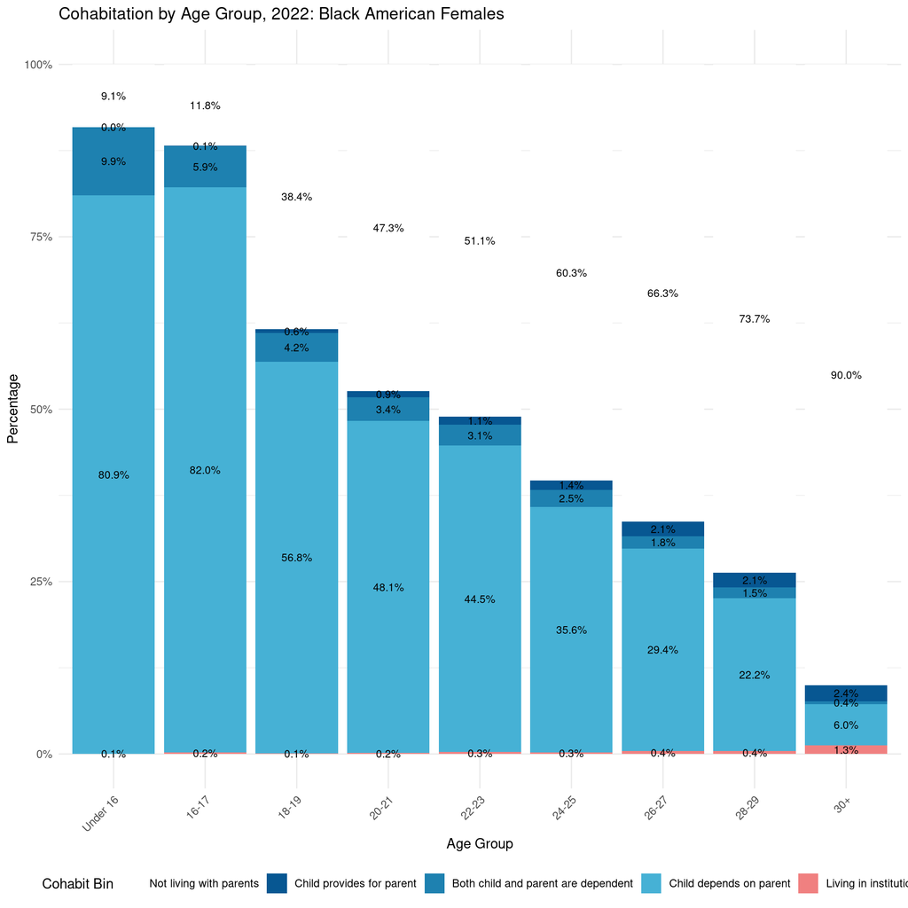

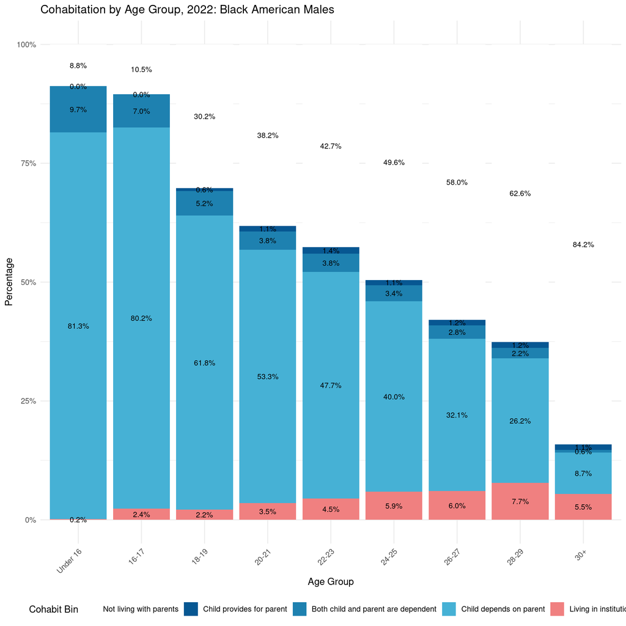

# Hispanic Americans

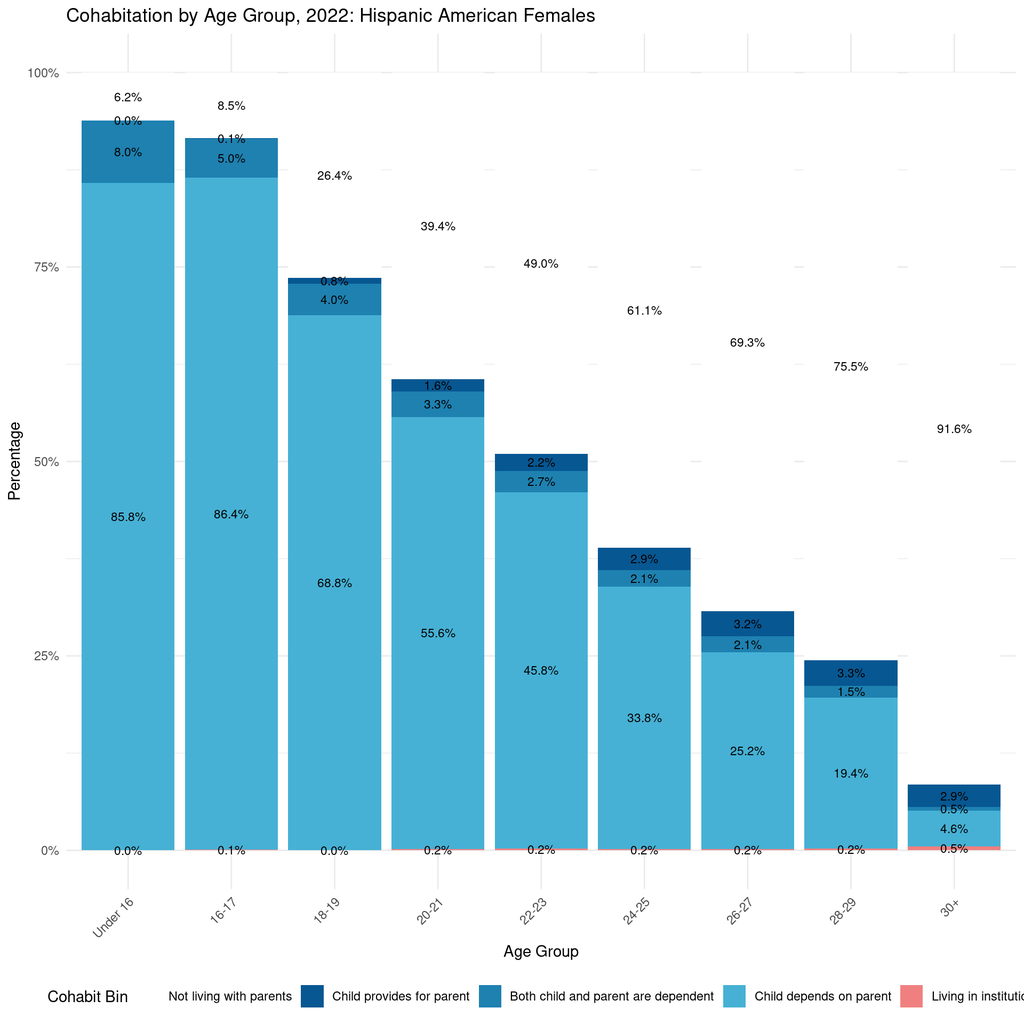

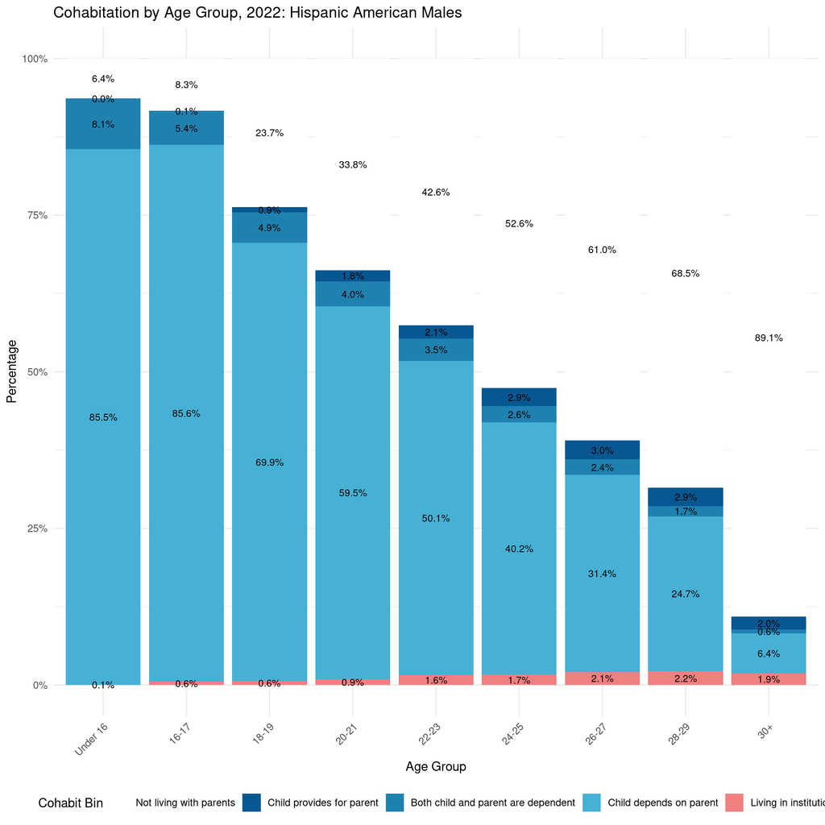

# Multiracial Americans

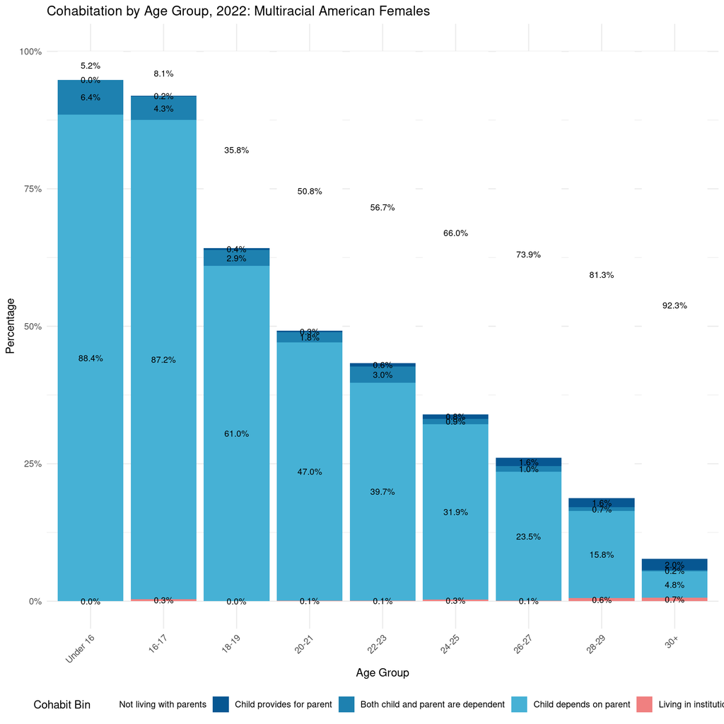

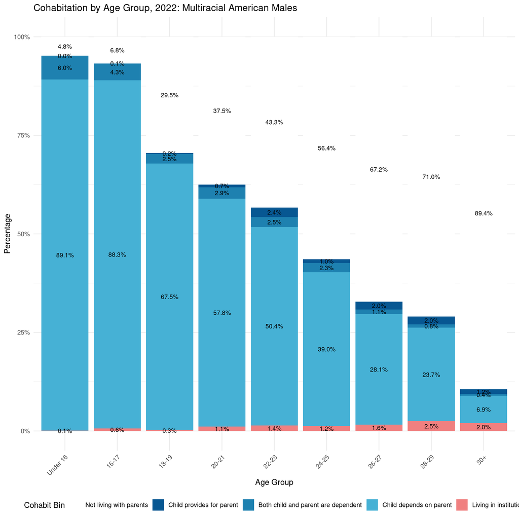

# White Americans

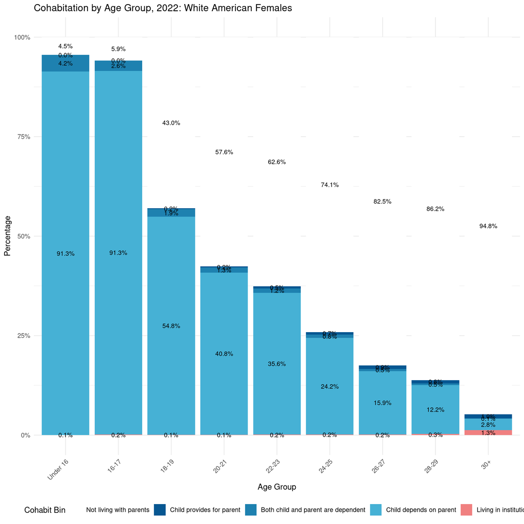

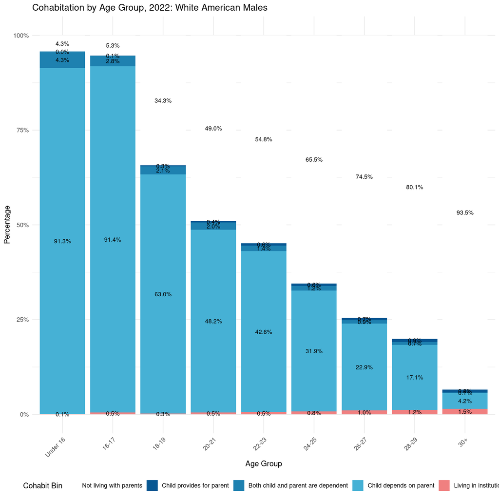

# Other Americans

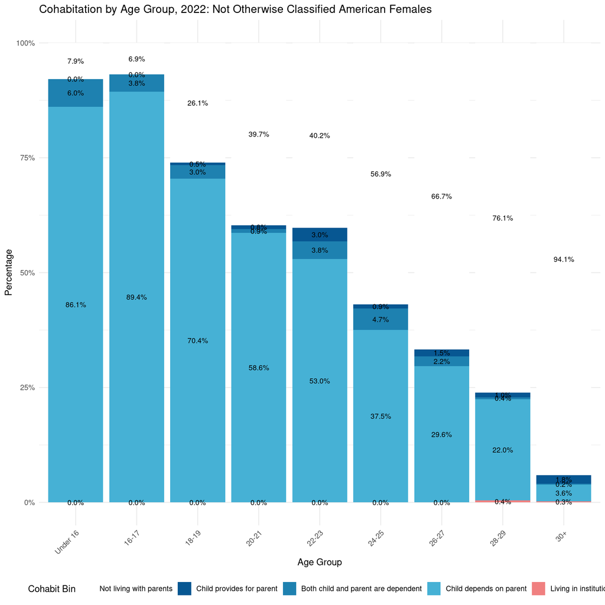

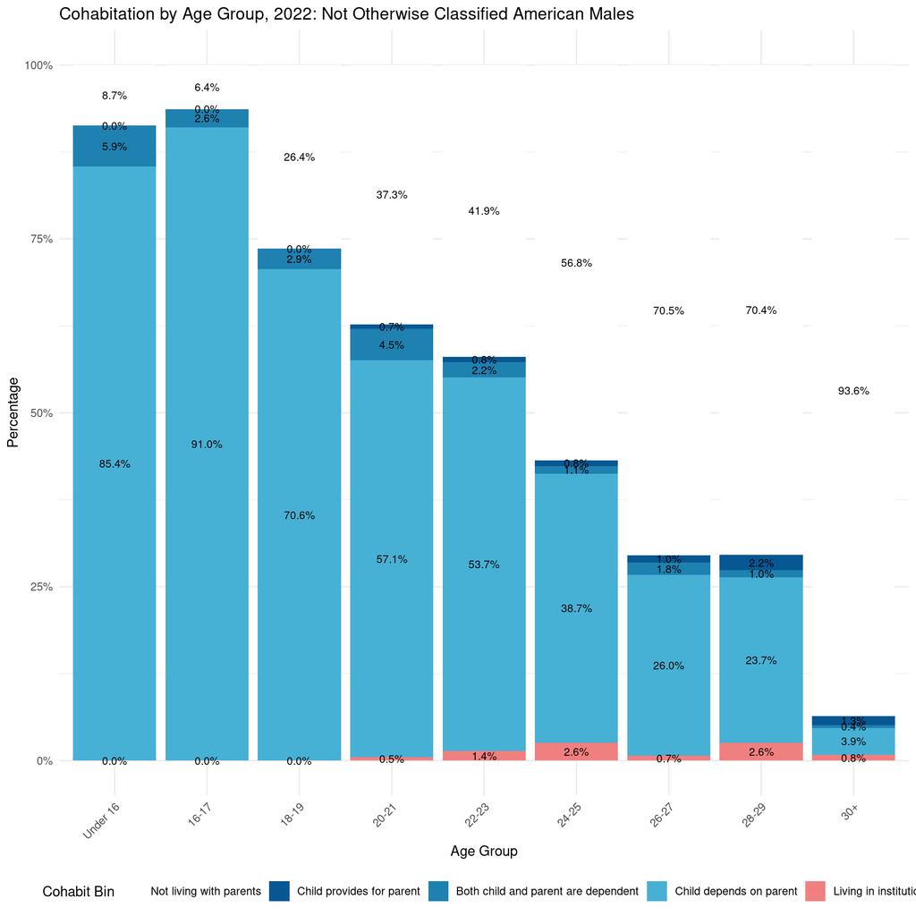